# Boost Converter: DCM

The boost converter given below has an input voltage of $V_i = 5\,V$. The average output voltage is $V_o = 10\,V$, and the load resistance is $5\,\Omega$. The switching frequency is $25\,$kHz, and $C = 220\,\mu$F. Determine the value of $L$ if $I_L\,$(peak-to-peak) is $3\times I_L^{\mathrm{avg}}$.

Evaluate the following quantities:

1. duty ratio
2. peak-to-peak ripple voltage across the capacitor
3. rms current through switch, diode, inductor, and capacitor

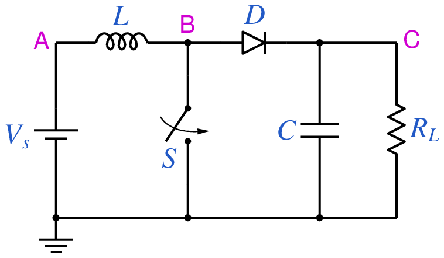

```python
from IPython.display import Image
Image(filename =r'boost_dcm_1_fig_1.png', width=320)
```

```python
# run this cell to view the circuit file.
%pycat boost_dcm_1_orig.in
```

```python
import gseim_calc as calc
s_Vin = '5'
s_L = '5.55u'
s_C = '220u'
s_R = '5'
s_D = '0.5' # to be changed by user
s_f_hz = '25e3'
l = [
  ('$Vin', s_Vin),
  ('$L', s_L),
  ('$C', s_C),
  ('$R', s_R),
  ('$D', s_D),
  ('$f_hz', s_f_hz)
]
calc.replace_strings_1("boost_dcm_1_orig.in", "boost_dcm_1.in", l)
print('boost_dcm_1.in is ready for execution')
```

```
boost_dcm_1.in is ready for execution
```

**Execute the following cell to run GSEIM on boost_dcm_1.in.**

```python
import os
import dos_unix
# uncomment for windows:
#dos_unix.d2u("boost_dcm_1.in")
os.system('run_gseim boost_dcm_1.in')
```

```
Circuit: filename = boost_dcm_1.in
main: calling solve_sss
solve_sss starting: sss_n_st: 2
solve_sss_ex: sss_iter_newton=0, rhs_sss_norm=3.6060e+01, sss_period_1_compute=8.0000e-05
solve_sss_ex: sss_iter_newton=1, rhs_sss_norm=6.4383e+00, sss_period_1_compute=8.0000e-05
solve_sss_ex: sss_iter_newton=2, rhs_sss_norm=6.2893e-05, sss_period_1_compute=8.0000e-05
solve_sss_ex: sss_iter_newton=3, rhs_sss_norm=7.3388e-06, sss_period_1_compute=8.0000e-05
solve_sss_ex: sss_iter_newton=4, rhs_sss_norm=5.9095e-08, sss_period_1_compute=8.0000e-05
solve_sss_ex: sss_iter_newton=5, rhs_sss_norm=2.2346e-10, sss_period_1_compute=8.0000e-05
solve_sss_ex: sss_iter_newton=6, rhs_sss_norm=9.1578e-13, sss_period_1_compute=8.0000e-05
solve_sss_ex: calling sss_solve_trns_ex for one more trns step
Transient simulation starts...
i=0
GSEIM: Program completed.
```

```
0
```

The circuit file (`boost_dcm_1.in`) is created in the same directory as that used for launching Jupyter notebook. The last step (i.e., running `GSEIM` on `boost_dcm_1.in`) creates a data file `boost_dcm_1.dat` in the same directory. We can now use the python code below to view the inductor current as a function of time.

```
filename: boost_dcm_1.dat
```

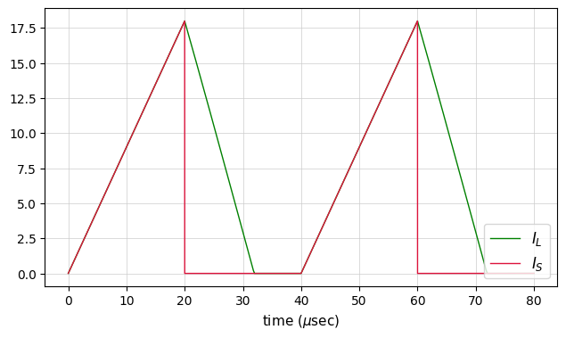

```python
import numpy as np
import matplotlib.pyplot as plt

from setsize import set_size

slv = calc.slv("boost_dcm_1.in")

i_slv = 0
i_out = 0
filename = slv.l_filename_all[i_slv][i_out]
print('filename:', filename)
u = np.loadtxt(filename)
t1 = u[:, 0]
t = t1*1e6 # convert time to micro-seconds

IL = slv.get_array_double(i_slv,i_out,"IL",u)
IS = slv.get_array_double(i_slv,i_out,"IS",u)
ID = slv.get_array_double(i_slv,i_out,"ID",u)
IC = slv.get_array_double(i_slv,i_out,"IC",u)
v_in = slv.get_array_double(i_slv,i_out,"v_in",u)
v_out = slv.get_array_double(i_slv,i_out,"v_out",u)
clock = slv.get_array_double(i_slv,i_out,"clock",u)

color1='green'
color2='crimson'
color3='goldenrod'
color4='blue'

fig, ax = plt.subplots()
plt.subplots_adjust(wspace=0, hspace=0.0)

set_size(5, 3.0, ax)

plt.grid(color='#CCCCCC', linestyle='solid', linewidth=0.5)

ax.plot(t, IL, color=color1, linewidth=1.0, label="$I_L$")
ax.plot(t, IS, color=color2, linewidth=1.0, label="$I_S$")

plt.xlabel('time (' + r'$\mu$' + 'sec)', fontsize=11)

ax.legend(loc = 'lower right',frameon = True, fontsize = 10, title = None,
   markerfirst = True, markerscale = 1.0, labelspacing = 0.5, columnspacing = 2.0,
   prop = {'size' : 12},)

plt.tight_layout()
plt.show()
```

```
filename: boost_dcm_1.dat
```

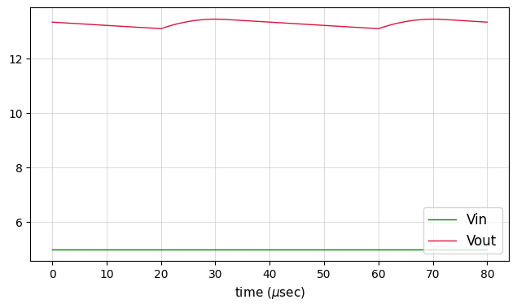

```python
import numpy as np
import matplotlib.pyplot as plt

from setsize import set_size

slv = calc.slv("boost_dcm_1.in")

i_slv = 0
i_out = 0
filename = slv.l_filename_all[i_slv][i_out]
print('filename:', filename)
u = np.loadtxt(filename)
t1 = u[:, 0]
t = t1*1e6 # convert time to micro-seconds

IL = slv.get_array_double(i_slv,i_out,"IL",u)
IS = slv.get_array_double(i_slv,i_out,"IS",u)
ID = slv.get_array_double(i_slv,i_out,"ID",u)
IC = slv.get_array_double(i_slv,i_out,"IC",u)
v_in = slv.get_array_double(i_slv,i_out,"v_in",u)
v_out = slv.get_array_double(i_slv,i_out,"v_out",u)
clock = slv.get_array_double(i_slv,i_out,"clock",u)

color1='green'
color2='crimson'
color3='goldenrod'
color4='blue'

fig, ax = plt.subplots()
plt.subplots_adjust(wspace=0, hspace=0.0)

set_size(5, 3.0, ax)

plt.grid(color='#CCCCCC', linestyle='solid', linewidth=0.5)

ax.plot(t, v_in, color=color1, linewidth=1.0, label="Vin")
ax.plot(t, v_out, color=color2, linewidth=1.0, label="Vout")

plt.xlabel('time (' + r'$\mu$' + 'sec)', fontsize=11)

ax.legend(loc = 'lower right',frameon = True, fontsize = 10, title = None,
   markerfirst = True, markerscale = 1.0, labelspacing = 0.5, columnspacing = 2.0,
   prop = {'size' : 12},)

plt.tight_layout()
plt.show()
```

On the output file produced by `GSEIM` (in this case, `boost_dcm_1.dat`), we can do some post-processing to obtain average and rms values, for example. For this purpose, a python module `gseim_calc.py` has been included in the directory from which you launched Jupyter. Run the following python script to obtain the quantities of interest listed in the question.

```python
import gseim_calc as calc
import numpy as np

slv = calc.slv("boost_dcm_1.in")

i_slv = 0
i_out = 0
filename = slv.l_filename_all[i_slv][i_out]
print('filename:', filename)
u = np.loadtxt(filename)
t = u[:, 0]

IL = slv.get_array_double(i_slv,i_out,"IL",u)
IS = slv.get_array_double(i_slv,i_out,"IS",u)
ID = slv.get_array_double(i_slv,i_out,"ID",u)
IC = slv.get_array_double(i_slv,i_out,"IC",u)
v_in = slv.get_array_double(i_slv,i_out,"v_in",u)
v_out = slv.get_array_double(i_slv,i_out,"v_out",u)
clock = slv.get_array_double(i_slv,i_out,"clock",u)

# since we have stored two cycles, we need to divide the last time point
# by 2 to get the period:

T = t[-1]/2

l_IL    = calc.avg_rms_3a(t, IL,    0.0, 2.0*T, 1.0e-3*T)
l_IS    = calc.avg_rms_3a(t, IS,    0.0, 2.0*T, 1.0e-3*T)
l_ID    = calc.avg_rms_3a(t, ID,    0.0, 2.0*T, 1.0e-3*T)
l_IC    = calc.avg_rms_3a(t, IC,    0.0, 2.0*T, 1.0e-3*T)
l_v_out = calc.avg_rms_3a(t, v_out, 0.0, 2.0*T, 1.0e-3*T)

t_start = 0.0
t_end = 2.0*T

l1 = calc.min_max_1(t, IL, t_start, t_end)
IL_ptop = l1[1] - l1[0]
print('IL_ptop:', "%11.4E"%IL_ptop)

l2 = calc.min_max_1(t, v_out, t_start, t_end)
VC_ptop = l2[1] - l2[0]
print('VC_ptop:', "%11.4E"%VC_ptop)

IL_rms = l_IL[1]
print('IL_rms:', "%11.4E"%IL_rms)
IL_avg = l_IL[0]
print('IL_avg:', "%11.4E"%IL_avg)
IS_rms = l_IS[1]
print('IS_rms:', "%11.4E"%IS_rms)
ID_rms = l_ID[1]
print('ID_rms:', "%11.4E"%ID_rms)
IC_rms = l_IC[1]
print('IC_rms:', "%11.4E"%IC_rms)
Vout_avg = l_v_out[0]
print('Vout_avg:', "%11.4E"%Vout_avg)
Vout_rms = l_v_out[1]
print('Vout_rms:', "%11.4E"%Vout_rms)
```

```
filename: boost_dcm_1.dat
IL_ptop:  1.7985E+01
VC_ptop:  3.5023E-01
IL_rms:  9.3005E+00
IL_avg:  7.2013E+00
IS_rms:  7.3487E+00
ID_rms:  5.7005E+00
IC_rms:  5.0206E+00
Vout_avg:  1.3287E+01
Vout_rms:  1.3287E+01
```

This notebook was contributed by **Prof. Nakul Narayanan K**, Govt. Engineering College, Thrissur. He may be contacted at nakul@gectcr.ac.in.